# Reports of Incident Types and Call Origin to Cheshire

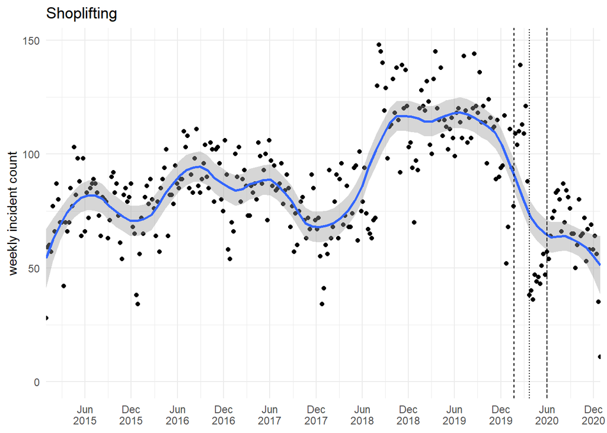

Overall the graph shows some cyclic movement with reports reflecting some random variation. However, a significant decreases is shown from the start of the pandemic. Again, this is reflective of shops and businesses being closed resulting in less suitable targets and opportunities for shoplifting. However, this could just following the decreasing trend.

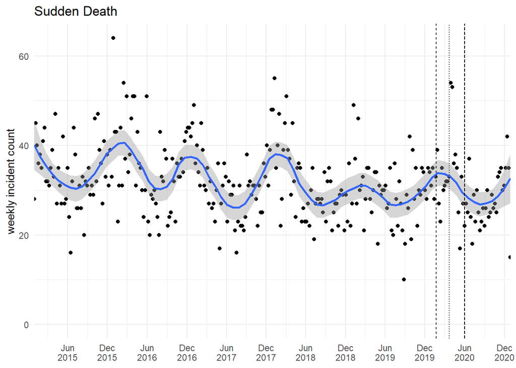

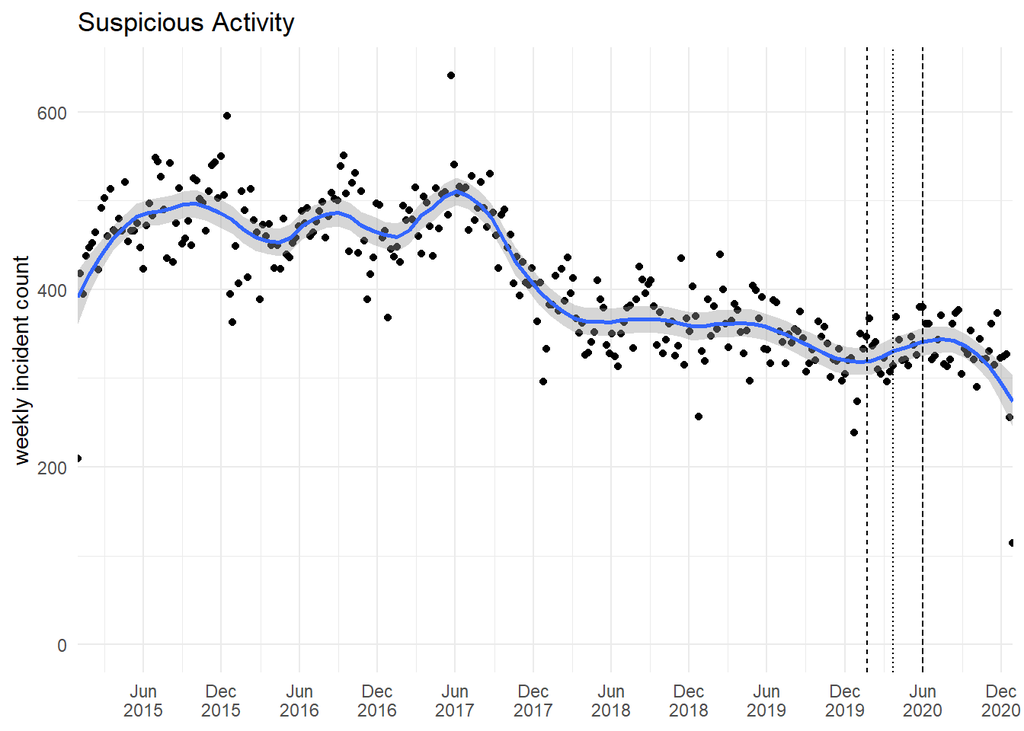

Overall there is a general decreasing trend of suspicious activity being reported. However, the average increases at the start of the first U.K case. This could be explained by possible reports of people breaking lockdown restrictions.

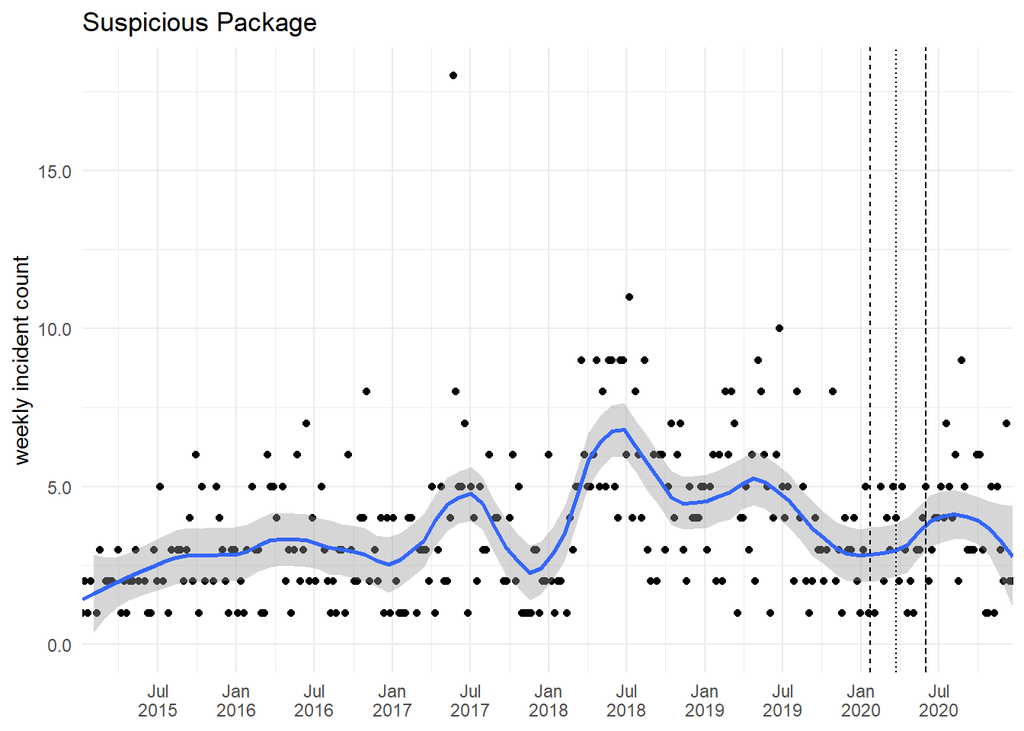

No significant trend or pattern

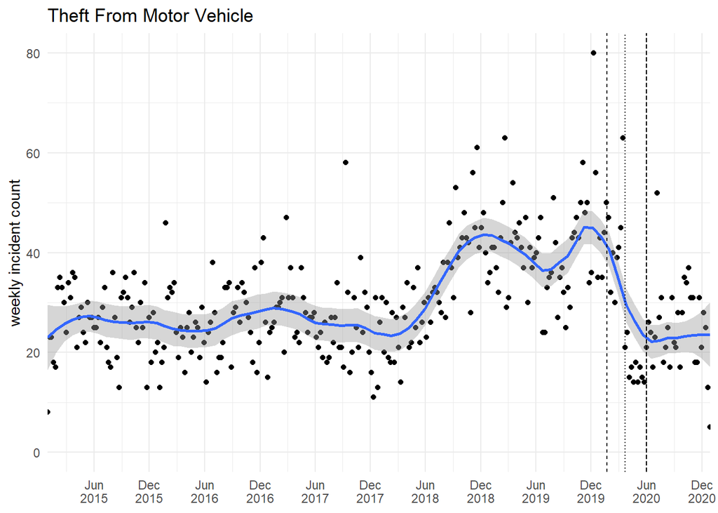

The data highlights no clear cyclical movement but rather random variation of theft from Motor Vehicles. There is however, a significant decrease in trends from the start of the first U.K case and the first U.K lockdown. This is what we would have expected to see as more people were working from home which reduces the opportunity of theft without being reported.

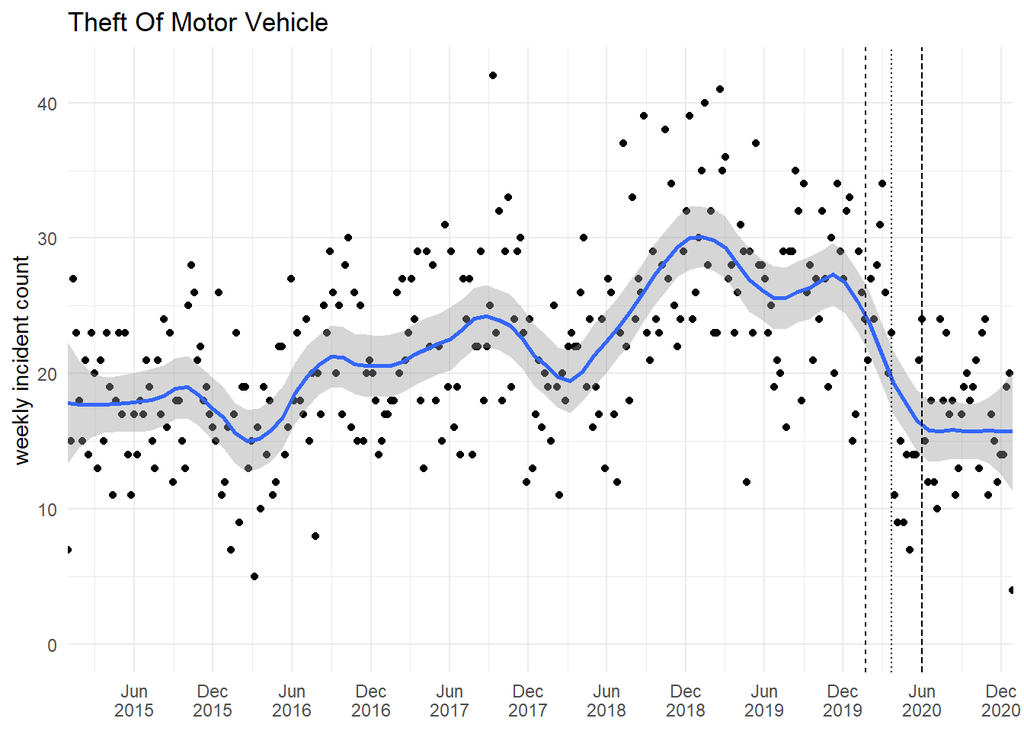

Results are similar to that of ‘theft from motor vechicle’ with a significant decrease over the start of the first U.K case and the first U.K lockdown. There is however, more apparent cyclical movement and noise.

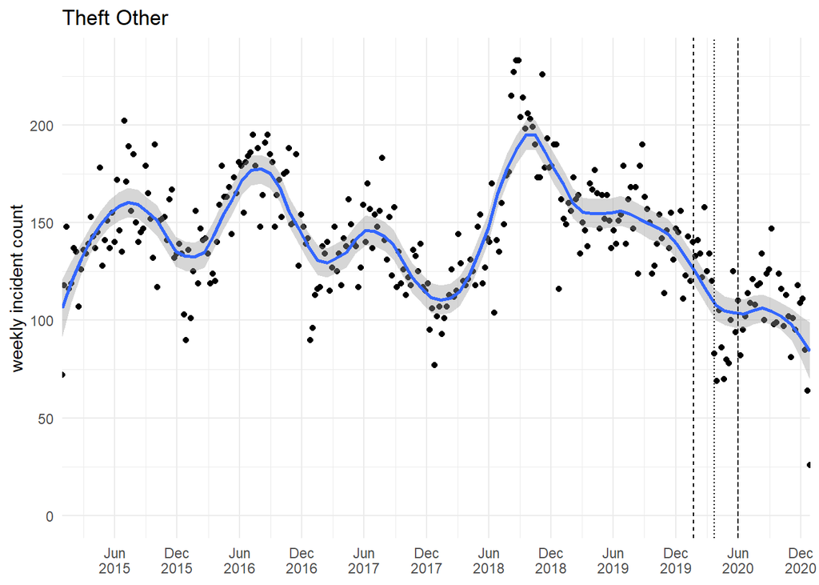

Again, we some some cyclical movement among other theft with a proportional decrease at the start of the lockdown.

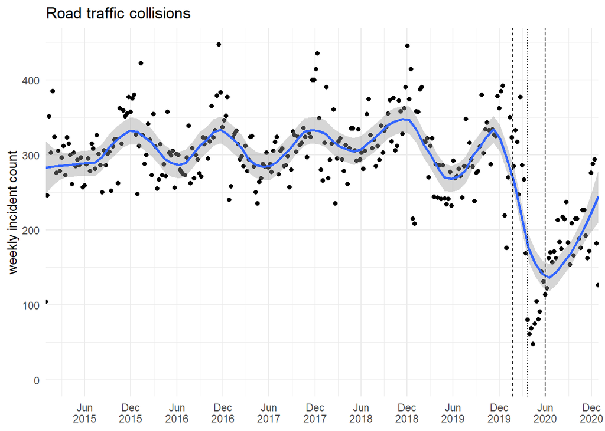

The above plot highlights seasonality and cyclical movement throughout the years with a noticeable decline at the the start of lockdown. This could be reflective of the travel restriction over the lockdown which reduced the presence of vehicles on the roads. This could also be supported by the sharp increase of traffic collusion after the first lockdown had been relieved.

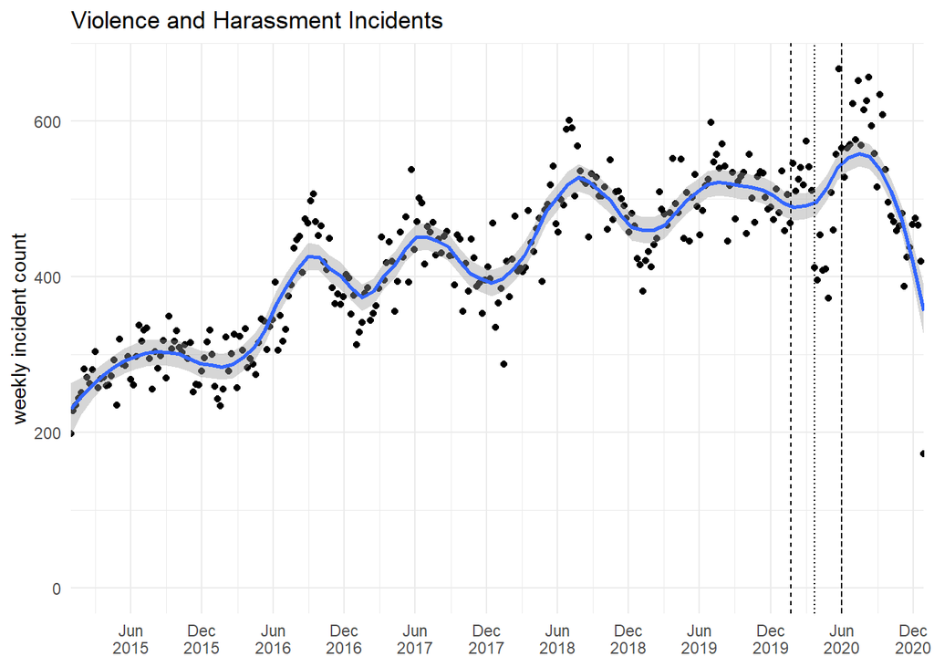

The plot highlights an increasing trend with some cyclical movement. This pattern is subsequently different over the start of the pandemic where there is some noise present

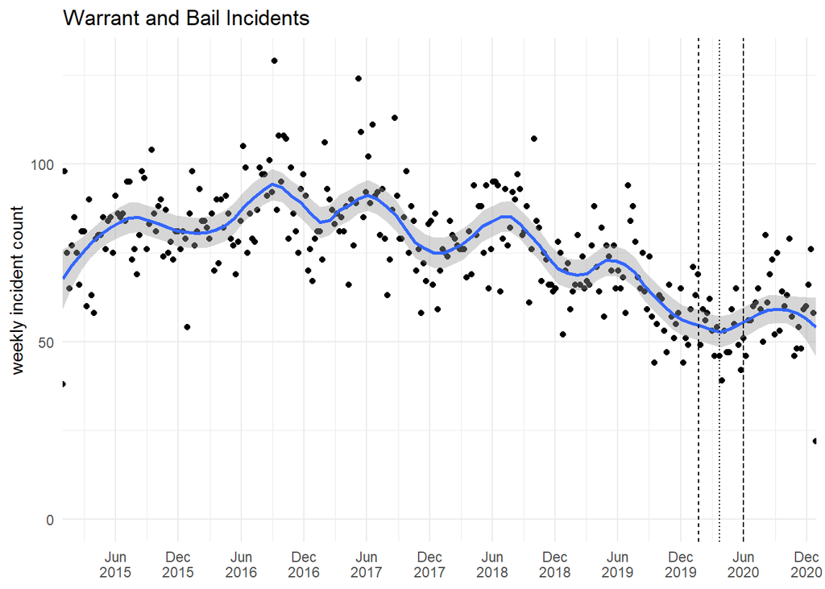

Although the graph follows a steady cyclical movements, there is a questionable reduction in warrant and bail incidents from the start of the pandemic. This could be reflective of a less opportunities to commit breaches.

# Changes in Proportions of Call Origin Over Time

In this part of the report, we highlight some simple bivariate descriptors and then highlight the proportion of call types over time.

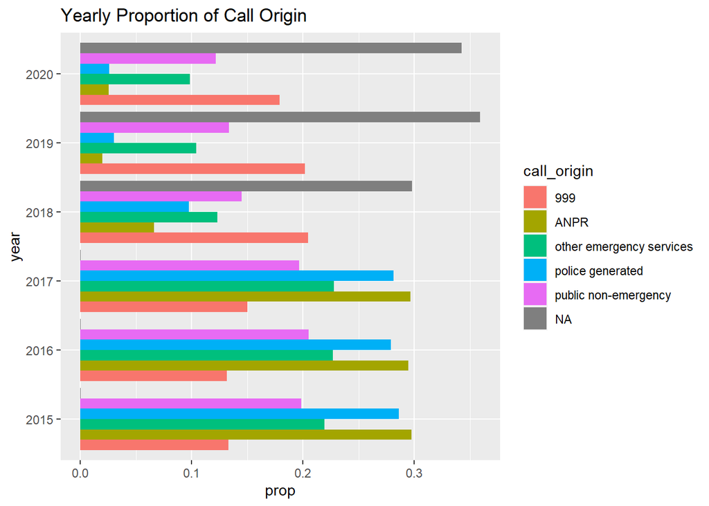

Why are NAs preent in 2018-2020? Is this representing the ‘unknown choice list value’?

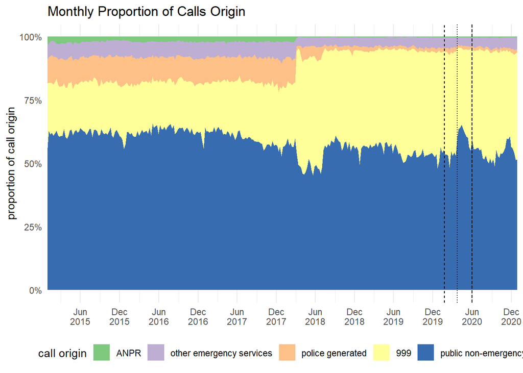

*Public non-emergency = Alarm Company, Email (to Public Contact Mailbox, Helpdesk, Public Non Emergency (inc. Door Phones and PCPs), Single Online Home and Social Media.

# Relationship Between Incident Type and Origin

The below graphs examine whether there is a difference in what is being reported and how this fluctuates over time within the different origin categories.

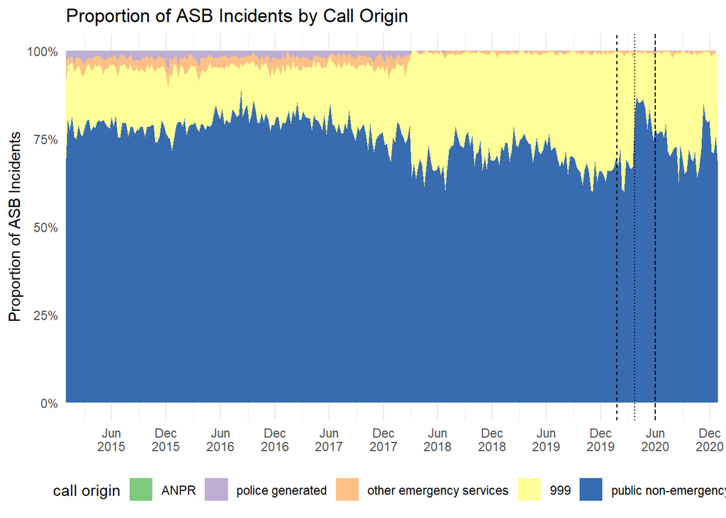

The largest origin type for ASB is that of public-non emergency. Following the first U.K lockdown their is also a significant increase of calls, which would support the literature. Additionally, there is a small but noticeable decrease in calls from the first known U.K case. Fluctuations in ASB calls, especially in the public non-emergency category, highlights a significant relationship between lockdown regulations and the effect on ASB.

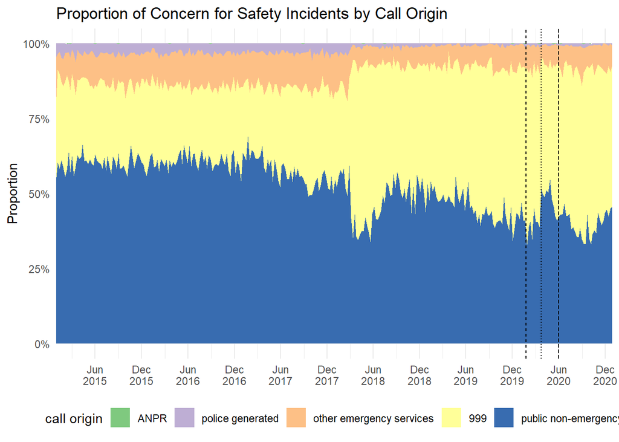

Some noticeable fluctuations in Public Non-Emergency within calls for safety; we see a large increase from the first U.K lockdown. This would also mean that there is less 999 calls being made and could be reflective of a decreased presence of people in everyday routines.

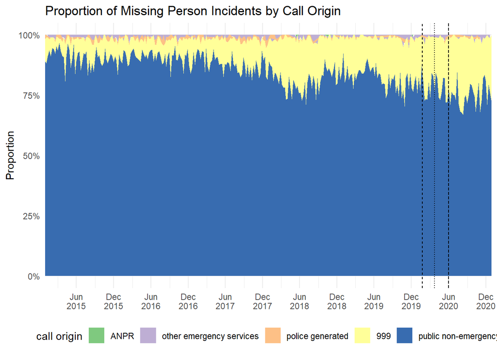

From the graph, it is hard to tell whether the rate of missing persons changed during and around the lockdown As the univariate analyses highlighted a lot of noise, further analysis would be recommended.

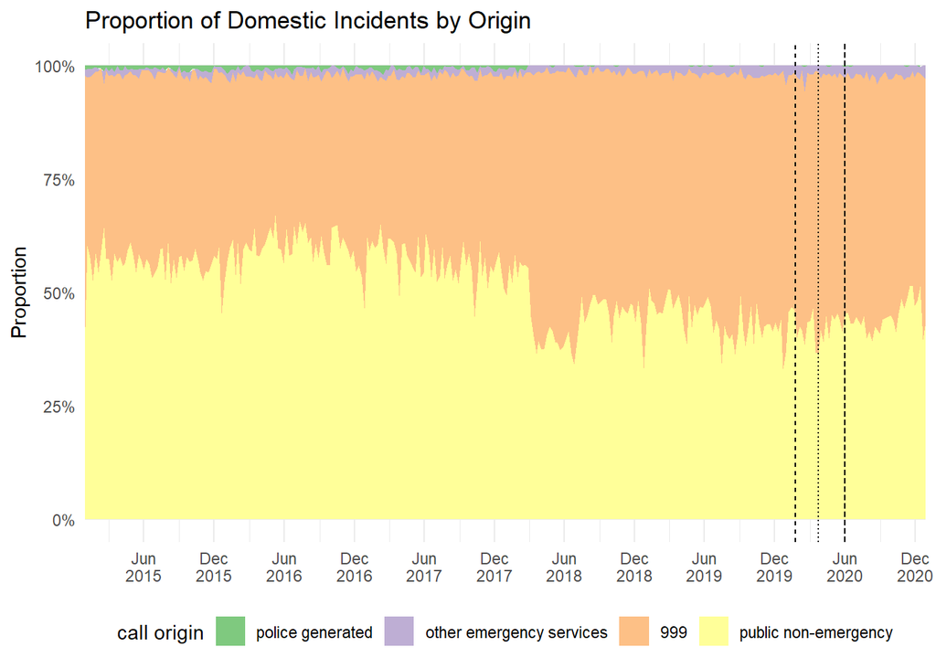

The majority of domestic incident calls are handled by 999 or PNE but the trend seems similar to that of previous years.

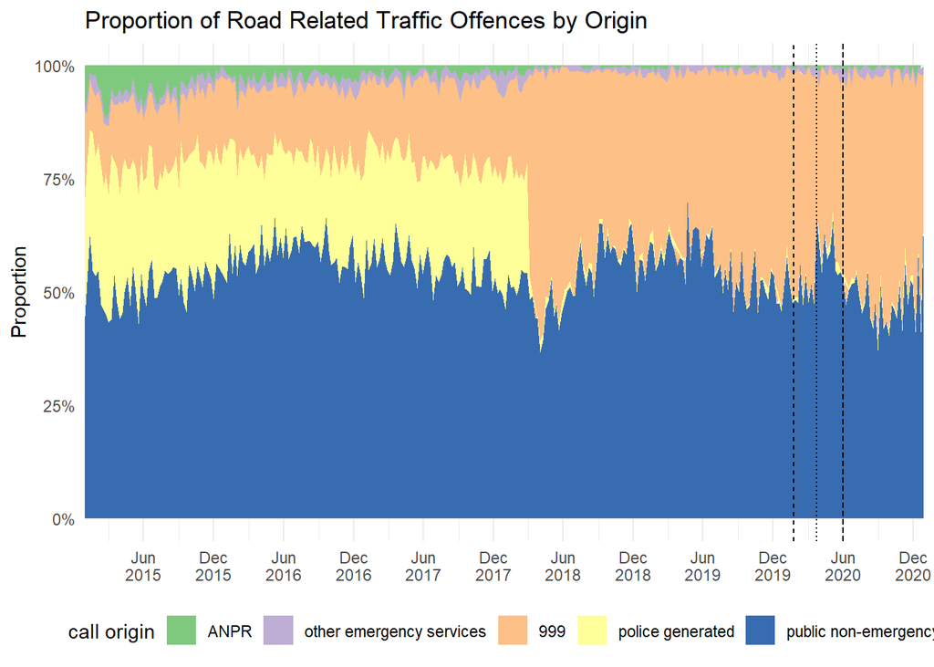

There is a significant increase in Public Non-Emergency receiving road related traffic offenses from the first U.K lockown. This is interesting because it would assume that either more people are committing traffic offenses or is it just that police were more inclined to report offenses due to the breaking of lockdown regulations and travel restrictions.

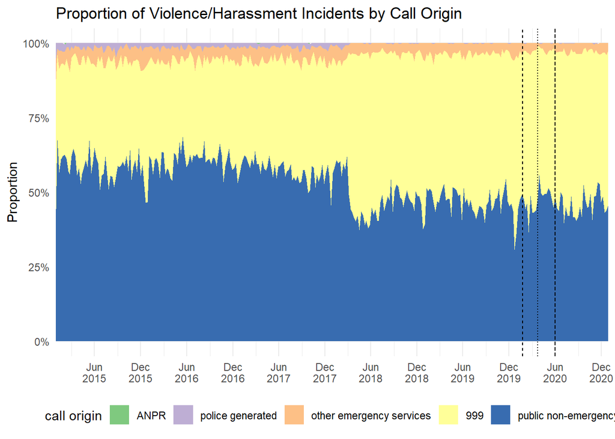

Some unequal distribution, with a small spike within the Public Non-Emergency category at the start of the lockdown.

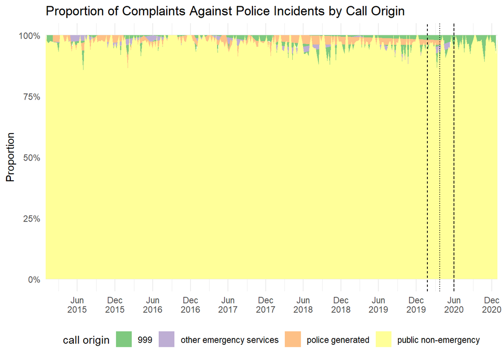

Data is not very clear. There is some unequal distribution but it would seem that complaints made against the police do not vary by call origin as the proportion is relatively constant across years. However, the proportion within the lockdown period shows some small differences, including the presence of complaints against police coming from other emergency services.

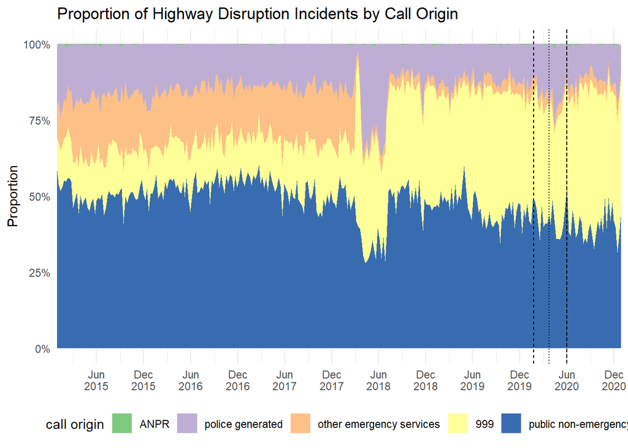

There seems to be some noticeable propotional change in the call origin for highway disruption, especially after the first U.k lockdown. There is a decline in reports from PNE and 999, and an increase in police generated

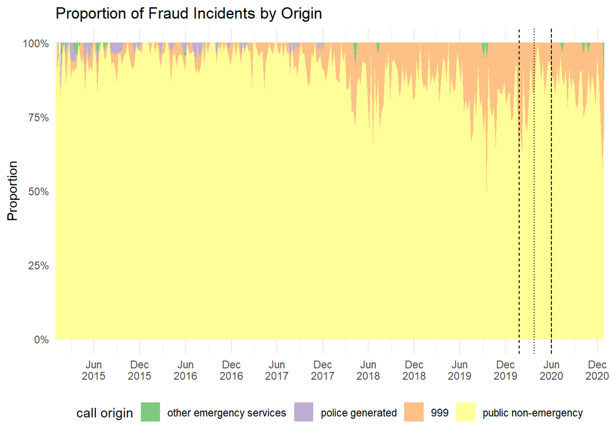

Interestingly there seems to be an increase in the reports of Fraud over from PNE. Although the spike is relatively larger following the the first U.K lockdwon, this could however, be a result of seasonality.

#Concluding Thoughts

This data gives an insight into the changing proportions of incident types and call origin over a 5 year period, with the additional focus on the changes in report statistics within the lockdown period. The plots that represent violent crimes would coincide with new literature supporting the change in crime patterns as a result of lockdown regulations/restrictions. Non-crime trends however, need further examination supported by the presence of noise and random variation within the plots.